# The Influence of Culture and Attachment Style on Attributions in Romantic Relationships

- Show All Code
- Hide All Code
- View Source

PSY 120L Reproducible Analysis Report

Author

Giselle Sanchez

Published

June 5, 2026

## About This Report

This reproducible report documents the data preparation, variable construction, descriptive statistics, primary analyses, and figures for this study.

The report is intended to accompany a manuscript-style research paper. It is not the full paper itself. Instead, it shows how the reported analyses were produced from the dataset using a transparent and reproducible Quarto workflow.

## Study Overview

This study examined whether attribution scores differed by scenario condition, culture group, attachment group, and their respective interactions.

The design included one manipulated independent variable and two moderators.

- Scenario condition: negative vignette condition versus positive vignette condition
- Culture group: low individualism versus high individualism
- Attachment group: insecure versus secure

The dependent variable was Relationship Attribution Measure (RAM) score.

The primary analyses tested whether whether scenario type, culture group, attachment group, and their respective interactions predicted RAM scores.

## Setup and Software Environment

This section loads the packages used for data preparation, scale construction, statistical modeling, estimated marginal means, and figures

**Load Packages**

```r
library(tidyverse)
library(psych)
library(afex)
library(emmeans)
```

## Data Source and Analysis Dataset

The dataset was imported from the project data folder. The imported dataset was saved as study_raw so that the original file remained unchanged throughout the report.

A smaller analysis dataset was then created for the current analyses. This dataset retained the study condition variables, demographic variables, culture items, attachment items, and RAM items needed for variables preparation analysis.

### Import Dataset

```r
study_raw <- read_csv("data/partner_perception_data.csv")
```

### Check Imported Dataset

```r
dim(study_raw)
```

```
[1] 73 29
```

```r
names(study_raw)
```

```
 [1] "ResponseId"          "DistributionChannel" "consent question"
 [4] "RAM_1"               "RAM_2"               "RAM_3"
 [7] "RAM_4"               "RAM_5"               "RAM_6"
[10] "cult_1"              "cult_2"              "cult_3"
[13] "cult_4"              "cult_5"              "cult_6"
[16] "cult_7"              "cult_8"              "cult_9"
[19] "cult_10"             "cult_11"             "cult_12"
[22] "cult_13"             "cult_14"             "cult_15"
[25] "cult_16"             "attach"              "gender"
[28] "age"                 "condition"
```

```r
head(study_raw)
```

```
# A tibble: 6 × 29
  ResponseId      DistributionChannel `consent question` RAM_1 RAM_2 RAM_3 RAM_4
  <chr>           <chr>                            <dbl> <dbl> <dbl> <dbl> <dbl>
1 R_5KlQgkEKaN7w… email                                1     3     2     5     2
2 R_1Dnpx3n2jc0w… email                                1     4     4     4     4
3 R_6wvN14pKrOr6… email                                1     4     4     5     3
4 R_5nXQ6vwj3mQ8… email                                1     4     3     3     3
5 R_3n1GcAbpGhwx… anonymous                            1     5     4     5     5
6 R_6QXgUHY5Wv3c… anonymous                            1     4     4     4     2
# ℹ 22 more variables: RAM_5 <dbl>, RAM_6 <dbl>, cult_1 <dbl>, cult_2 <dbl>,
#   cult_3 <dbl>, cult_4 <dbl>, cult_5 <dbl>, cult_6 <dbl>, cult_7 <dbl>,
#   cult_8 <dbl>, cult_9 <dbl>, cult_10 <dbl>, cult_11 <dbl>, cult_12 <dbl>,
#   cult_13 <dbl>, cult_14 <dbl>, cult_15 <dbl>, cult_16 <dbl>, attach <dbl>,
#   gender <dbl>, age <chr>, condition <dbl>
```

The import checks confirm that the dataset loaded successfully, show the number of rows and columns, and display the variable names available in the original dataset.

### Create Analysis Dataset

```r
study_vars <- c(
  "condition", "age", "gender", "attach",

  "RAM_1", "RAM_2", "RAM_3", "RAM_4", "RAM_5", "RAM_6",

  "cult_1", "cult_2", "cult_3", "cult_4",
  "cult_5", "cult_6", "cult_7", "cult_8",
  "cult_9", "cult_10", "cult_11", "cult_12",
  "cult_13", "cult_14", "cult_15", "cult_16"
)

study_data <- study_raw %>%
  select(all_of(study_vars)) %>%
  mutate(
    across(everything(), as.numeric)
  )
```

### Check Analysis Dataset

```r
length(study_vars)
```

```
[1] 26
```

```r
dim(study_data)
```

```
[1] 73 26
```

```r
names(study_data)
```

```
 [1] "condition" "age"       "gender"    "attach"    "RAM_1"     "RAM_2"
 [7] "RAM_3"     "RAM_4"     "RAM_5"     "RAM_6"     "cult_1"    "cult_2"
[13] "cult_3"    "cult_4"    "cult_5"    "cult_6"    "cult_7"    "cult_8"
[19] "cult_9"    "cult_10"   "cult_11"   "cult_12"   "cult_13"   "cult_14"
[25] "cult_15"   "cult_16"
```

The analysis dataset contains the variables required for the report. The checks confirm the number of variables, the dimensions of the analysis dataset, and the final variable names carried forward into the preparation and analysis sections.

## Variable Preparation

This section prepares the variables used in the primary analyses. The original imported dataset was left unchanged; all prepared variables were created in the working analysis dataset, study_data.

### Prepare Participant ID and Experimental Condition

```r
study_data <- study_data %>%
  mutate(
    id = row_number(),
    condition = factor(
      condition,
      levels = c(0, 1),
      labels = c("Negative", "Positive")
    )
  )
```

The experimental condition variable was recoded as a labeled factor with two levels: Negative and Positive. A participant ID variable was also created so that each row in the analysis dataset had a unique identifier.

### Check Experimental Condition Coding

```r
study_data %>%
  count(condition) %>%
  knitr::kable(
    col.names = c("Condition", "n")
  )
```

| Condition | n |
| --- | --- |
| Negative | 38 |
| Positive | 35 |

The condition check confirms the number of participants assigned to each scenario condition.

### Check Prepared Analysis Dataset

```r
dim(study_data)
```

```
[1] 73 27
```

```r
names(study_data)
```

```
 [1] "condition" "age"       "gender"    "attach"    "RAM_1"     "RAM_2"
 [7] "RAM_3"     "RAM_4"     "RAM_5"     "RAM_6"     "cult_1"    "cult_2"
[13] "cult_3"    "cult_4"    "cult_5"    "cult_6"    "cult_7"    "cult_8"
[19] "cult_9"    "cult_10"   "cult_11"   "cult_12"   "cult_13"   "cult_14"
[25] "cult_15"   "cult_16"   "id"
```

The prepared analysis dataset contains the variables needed for scale construction, descriptive statistics, and primary analyses.

### Reverse-Code Scale Items

Items requiring reverse coding were transformed before scale scores were computed. Because the items used a 1-9 response scale, reverse-coded items were created by subtracting each original item response from 10.

```r
study_data <- study_data %>%
  mutate(
    cult_2r = 10 - cult_2,
    cult_4r = 10 - cult_4,
    cult_7r = 10 - cult_7,
    cult_8r = 10 - cult_8,
    cult_11r = 10 - cult_11,
    cult_12r = 10 - cult_12,
    cult_15r = 10 - cult_15,
    cult_16r = 10 - cult_16
  )
```

### Check Reverse Coding

```r
study_data %>%
  select(cult_2, cult_2r, cult_4, cult_4r, cult_7, cult_7r) %>%
  head(10) %>%
  knitr::kable()
```

| cult_2 | cult_2r | cult_4 | cult_4r | cult_7 | cult_7r |
| --- | --- | --- | --- | --- | --- |
| 6 | 4 | 3 | 7 | 7 | 3 |
| 5 | 5 | 5 | 5 | 5 | 5 |
| 8 | 2 | 2 | 8 | 7 | 3 |
| 6 | 4 | 7 | 3 | 8 | 2 |
| 8 | 2 | 8 | 2 | 8 | 2 |
| 8 | 2 | 3 | 7 | 7 | 3 |
| 7 | 3 | 9 | 1 | 8 | 2 |
| 9 | 1 | 6 | 4 | 9 | 1 |
| 8 | 2 | 7 | 3 | 7 | 3 |
| 9 | 1 | 7 | 3 | 9 | 1 |

The reverse-coding check shows examples of original and reverse-coded item pairs. These checks confirm that reverse-coded variables were created before scale scores were computed.

### Create Scale Scores

Scale item lists were defined and used to compute RAM and culture scale scores.

```r
RAM_items <- c(
  "RAM_1", "RAM_2", "RAM_3", "RAM_4", "RAM_5", "RAM_6"
)

culture_items <- c(
  "cult_1", "cult_2r", "cult_3", "cult_4r",
  "cult_5", "cult_6", "cult_7r", "cult_8r",
  "cult_9", "cult_10", "cult_11r", "cult_12r",
  "cult_13", "cult_14", "cult_15r", "cult_16r"
)

study_data <- study_data %>%
  mutate(
    RAM_scale = rowMeans(across(all_of(RAM_items)), na.rm = TRUE),
    culture_scale = rowMeans(across(all_of(culture_items)), na.rm = TRUE)
  )
```

### Check Scale Scores

```r
study_data %>%
  select(
    RAM_scale,
    culture_scale
  ) %>%
  summary()
```

```
   RAM_scale     culture_scale
 Min.   :1.833   Min.   :3.062
 1st Qu.:3.167   1st Qu.:4.250
 Median :3.500   Median :4.562
 Mean   :3.548   Mean   :4.558
 3rd Qu.:4.167   3rd Qu.:4.875
 Max.   :5.000   Max.   :6.000
```

```r
study_data %>%
  summarise(
    RAM_scale_missing = mean(is.na(RAM_scale)),
    culture_scale_missing = mean(is.na(culture_scale))
  ) %>%
  knitr::kable()
```

| RAM_scale_missing | culture_scale_missing |
| --- | --- |
| 0 | 0 |

The scale-score checks confirm that the computed scale scores fall within the expected response range and show whether any scale scores are missing.

### Create Attachment Groups

Insecure/Secure attachment grouping categories were created for the planned 2 x 2 ANOVA models. Participants who chose option 1 were labeled as secure and participants who chose options 2 or 3 were labeled as insecure. The moderator variables were then recoded as a labeled factor with two levels: Insecure and Secure.

```r
study_data <- study_data %>%
  mutate(
    attach_group = case_when(
      attach == 1 ~ "Secure",
      attach %in% c(2, 3) ~ "Insecure",
      TRUE ~ NA_character_
    ),
    attach_group = factor(
      attach_group,
      levels = c("Insecure", "Secure")
    )
  )

study_data %>%
  count(attach_group) %>%
  knitr::kable()
```

| attach_group | n |
| --- | --- |
| Insecure | 44 |
| Secure | 29 |

The attachment group check confirms the number of participants who were categorized to each attachment group.

### Create Culture Median Split

A low/high culture grouping variables was created for the planned 2 x 2 ANOVA models. Participants with Individualism scores at or below the samples median were assigned to the Low group, and participants above the sample median were assigned to the High group.

```r
culture_median <- median(study_data$culture_scale, na.rm = TRUE)

study_data <- study_data %>%
  mutate(
    culture_msplit = if_else(culture_scale <= culture_median, "Low", "High"),
    culture_msplit = factor(culture_msplit, levels = c("Low", "High"))
  )

culture_median
```

```
[1] 4.5625
```

```r
study_data %>%
  count(culture_msplit) %>%
  knitr::kable()
```

| culture_msplit | n |
| --- | --- |
| Low | 40 |
| High | 33 |

The median split created the culture grouping variable used in the primary ANOVA models. The output reports the median value used for the split and the number of participants assigned to each culture group.

### Check Scale Reliability

Internal consistency was estimated for the RAM and culture scales before the scale scores were used in the primary analyses

```r
RAM_item_df <- study_data %>%
  select(all_of(RAM_items))

culture_item_df <- study_data %>%
  select(all_of(culture_items))

RAM_alpha <- psych::alpha(RAM_item_df)
```

```
Some items ( RAM_5 RAM_6 ) were negatively correlated with the first principal component and
probably should be reversed.
To do this, run the function again with the 'check.keys=TRUE' option
```

```r
RAM_omega <- psych::omega(RAM_item_df, plot = FALSE)

culture_alpha <- psych::alpha(culture_item_df)
```

```
Some items ( cult_1 cult_3 cult_6 cult_9 cult_10 cult_13 cult_14 ) were negatively correlated with the first principal component and
probably should be reversed.
To do this, run the function again with the 'check.keys=TRUE' option
```

```r
culture_omega <- psych::omega(culture_item_df, plot = FALSE)

tibble(
  scale = c(
    "Relationship Attribution Measure",
    "Individualism and Collectivism Scale"
  ),
  alpha = c(
    RAM_alpha$total$raw_alpha,
    culture_alpha$total$raw_alpha
  ),
  omega = c(
    RAM_omega$omega.tot,
    culture_omega$omega.tot
  )
) %>%
  knitr::kable(digits = 2)
```

| scale | alpha | omega |
| --- | --- | --- |
| Relationship Attribution Measure | 0.42 | 0.82 |
| Individualism and Collectivism Scale | 0.40 | 0.84 |

The reliabliity table reports Cronbach’s alpha and McDonald’s omega for each scale used in the analysis.

## Descriptive Statistics

This section summarizes the scale scores and sample composition before the primary hypothesis tests.

### Scale Score Descriptives

```r
study_data %>%
  select(
    RAM_scale,
    culture_scale
  ) %>%
  psych::describe() %>%
  knitr::kable(digits = 2)
```

|  | vars | n | mean | sd | median | trimmed | mad | min | max | range | skew | kurtosis | se |
| --- | --- | --- | --- | --- | --- | --- | --- | --- | --- | --- | --- | --- | --- |
| RAM_scale | 1 | 73 | 3.55 | 0.71 | 3.50 | 3.60 | 0.74 | 1.83 | 5 | 3.17 | -0.51 | -0.10 | 0.08 |
| culture_scale | 2 | 73 | 4.56 | 0.61 | 4.56 | 4.56 | 0.46 | 3.06 | 6 | 2.94 | 0.00 | 0.02 | 0.07 |

This table reports descriptive statistics for the RAM and culture scale scores used in the primary analyses.

### Sample Composition by Age and Gender

```r
study_data %>%
  summarise(
    mean_age = mean(age, na.rm = TRUE),
    sd_age = sd(age, na.rm = TRUE),
    min_age = min(age, na.rm = TRUE),
    max_age = max(age, na.rm = TRUE)
  ) %>%
  knitr::kable(
    digits = 2,
    col.names = c("Mean", "SD", "Minimum", "Maximum"),
    caption = "Sample Age: Mean, Standard Deviation, and Range"
  )
```

Sample Age: Mean, Standard Deviation, and Range

| Mean | SD | Minimum | Maximum |
| --- | --- | --- | --- |
| 21.42 | 1.33 | 18 | 26 |

```r
study_data %>%
  mutate(
    gender_group = factor(
      gender,
      levels = c(1, 2, 3),
      labels = c("Male", "Female", "Non-binary / Other")
    )
  ) %>%
  count(gender_group) %>%
  mutate(percent = round(100 * n / sum(n), 1)) %>%
  knitr::kable(
    col.names = c("Gender", "n", "Percent"),
    caption = "Sample Composition by Gender"
  )
```

Sample Composition by Gender

| Gender | n | Percent |
| --- | --- | --- |
| Male | 10 | 13.7 |
| Female | 61 | 83.6 |
| Non-binary / Other | 2 | 2.7 |

The table reports the mean, standard deviation, minimum, and maximum age of participants. The table also reports the number and percentage of participants in each gender category.

## Correlations Among the Moderator and DV

The section shows the correlation values between the main continuous study variables; RAM and culture.

```r
psych::corr.test(
  study_data %>%
    select(
      RAM_scale,
      culture_scale
    )
)
```

```
Call:psych::corr.test(x = study_data %>% select(RAM_scale, culture_scale))
Correlation matrix
              RAM_scale culture_scale
RAM_scale          1.00          0.13
culture_scale      0.13          1.00
Sample Size
[1] 73
Probability values (Entries above the diagonal are adjusted for multiple tests.)
              RAM_scale culture_scale
RAM_scale          0.00          0.28
culture_scale      0.28          0.00

 To see confidence intervals of the correlations, print with the short=FALSE option
```

The data shows the significant tests for the correlation between RAM and culture scale scores.

## Primary Analyses

This section reports the primary analyses used to test whether scenario type, culture group, attachment group, and their respective interactions predicted RAM scores.

Two 2 x 2 ANOVA models were estimated. In both models, scenario condition was the manipulated independent variable and RAM score was the dependent variable. The first model used attachment group as the moderator and the second model used culture group as the moderator.

### **RAM Model with Attachment**

A 2 x 2 ANOVA tested whether RAM scores differed by scenario condition, attachment group, and the scenario condition x attachment group interaction.

```r
a1_RAM <- afex::aov_ez(
  id = "id",
  dv = "RAM_scale",
  between = c("condition", "attach_group"),
  data = study_data
)

a1_RAM
```

```
Anova Table (Type 3 tests)

Response: RAM_scale
                  Effect    df  MSE    F   ges p.value
1              condition 1, 69 0.51 2.49  .035    .119
2           attach_group 1, 69 0.51 0.04 <.001    .847
3 condition:attach_group 1, 69 0.51 0.15  .002    .700
---
Signif. codes:  0 '***' 0.001 '**' 0.01 '*' 0.05 '+' 0.1 ' ' 1
```

The ANOVA table reports the main effect of scenario condition, the main effect of attachment group, and the scenario condition x attachment group interaction for RAM scores.

### Estimated Means for RAM with Attachment

```r
emmeans(a1_RAM, ~ condition)
```

```
 condition emmean    SE df lower.CL upper.CL
 Negative    3.42 0.118 69     3.19     3.66
 Positive    3.69 0.125 69     3.44     3.94

Results are averaged over the levels of: attach_group
Confidence level used: 0.95
```

```r
emmeans(a1_RAM, ~ attach_group)
```

```
 attach_group emmean    SE df lower.CL upper.CL
 Insecure       3.54 0.108 69     3.33     3.76
 Secure         3.57 0.134 69     3.31     3.84

Results are averaged over the levels of: condition
Confidence level used: 0.95
```

```r
emmeans(a1_RAM, ~ condition * attach_group)
```

```
 condition attach_group emmean    SE df lower.CL upper.CL
 Negative  Insecure       3.44 0.153 69     3.13     3.74
 Positive  Insecure       3.64 0.153 69     3.34     3.95
 Negative  Secure         3.41 0.179 69     3.05     3.76
 Positive  Secure         3.74 0.199 69     3.35     4.14

Confidence level used: 0.95
```

The estimated means show the RAM score pattern across scenario condition, attachment group, and their combined cells.

### **RAM** Model with Culture

A 2 x 2 ANOVA tested whether RAM scores differed by scenario condition, culture group, and the scenario condition x culture group interaction.

```r
a2_RAM_culture <- afex::aov_ez(
  id = "id",
  dv = "RAM_scale",
  between = c("condition", "culture_msplit"),
  data = study_data
)

a2_RAM_culture
```

```
Anova Table (Type 3 tests)

Response: RAM_scale
                    Effect    df  MSE      F  ges p.value
1                condition 1, 69 0.48   1.86 .026    .177
2           culture_msplit 1, 69 0.48   0.31 .004    .581
3 condition:culture_msplit 1, 69 0.48 4.02 * .055    .049
---
Signif. codes:  0 '***' 0.001 '**' 0.01 '*' 0.05 '+' 0.1 ' ' 1
```

The ANOVA table reports the main effect of scenario condition, the main effect of culture group, and the scenario condition x culture group interaction for RAM scores.

### Estimated Means for RAM with Culture

```r
emmeans(a2_RAM_culture, ~ condition)
```

```
 condition emmean    SE df lower.CL upper.CL
 Negative    3.45 0.113 69     3.22     3.67
 Positive    3.67 0.118 69     3.44     3.91

Results are averaged over the levels of: culture_msplit
Confidence level used: 0.95
```

```r
emmeans(a2_RAM_culture, ~ culture_msplit)
```

```
 culture_msplit emmean    SE df lower.CL upper.CL
 Low              3.51 0.110 69     3.29     3.73
 High             3.60 0.121 69     3.36     3.85

Results are averaged over the levels of: condition
Confidence level used: 0.95
```

```r
emmeans(a2_RAM_culture, ~ condition * culture_msplit)
```

```
 condition culture_msplit emmean    SE df lower.CL upper.CL
 Negative  Low              3.24 0.152 69     2.94     3.54
 Positive  Low              3.79 0.159 69     3.47     4.11
 Negative  High             3.66 0.169 69     3.32     3.99
 Positive  High             3.55 0.174 69     3.21     3.90

Confidence level used: 0.95
```

The estimated means show the RAM score pattern across scenario condition, culture group, and their combined cells.

## Figures

This section creates the figures used to visualize the primary 2 x 2 ANOVA results. The figures are based on the estimated cell means from the ANOVA models.

### RAM with Attachment Interaction Plot

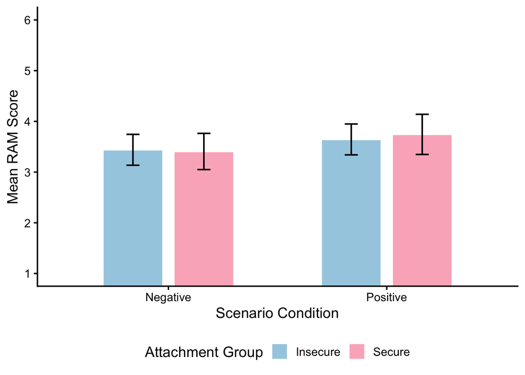

```r
p_RAM_attachment_bar <- ggplot(
  as.data.frame(emmeans(a1_RAM, ~ condition * attach_group)),
  aes(
    x = condition,
    y = emmean,
    fill = attach_group
  )
) +
  geom_col(
    position = position_dodge(width = 0.65),
    width = 0.55,
    color = "white"
  ) +
  geom_errorbar(
    aes(
      ymin = lower.CL,
      ymax = upper.CL
    ),
    position = position_dodge(width = 0.65),
    width = 0.12,
    linewidth = 0.7
  ) +
  labs(
    x = "Scenario Condition",
    y = "Mean RAM Score",
    fill = "Attachment Group"
  ) +
  scale_fill_manual(
    values = c(
      "Insecure" = "#A6CEE3",
      "Secure" = "#FBB4C4"
    )
  ) +
  scale_y_continuous(
    breaks = seq(1, 6, 1)
  ) +
  coord_cartesian(
    ylim = c(1, 6)
  ) +
  theme_classic(
    base_size = 14
  ) +
  theme(
    legend.position = "bottom"
  )

p_RAM_attachment_bar
```

The figure shows mean RAM scores by scenario condition and attachment group. Error bars represent 95% confidence intervals.

### RAM with Culture Interaction Plot

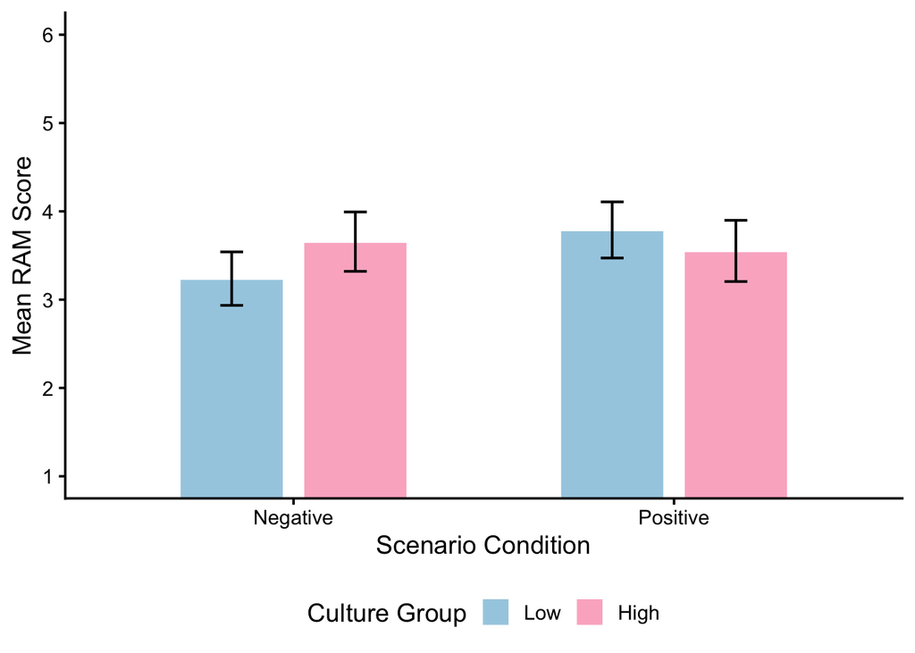

```r
p_culture_bar <- ggplot(
  as.data.frame(emmeans(a2_RAM_culture, ~ condition * culture_msplit)),
  aes(
    x = condition,
    y = emmean,
    fill = culture_msplit
  )
) +
  geom_col(
    position = position_dodge(width = 0.65),
    width = 0.55,
    color = "white"
  ) +
  geom_errorbar(
    aes(
      ymin = lower.CL,
      ymax = upper.CL
    ),
    position = position_dodge(width = 0.65),
    width = 0.12,
    linewidth = 0.7
  ) +
  labs(
    x = "Scenario Condition",
    y = "Mean RAM Score",
    fill = "Culture Group"
  ) +
  scale_fill_manual(
    values = c(
      "Low" = "#A6CEE3",
      "High" = "#FBB4CA"
    )
  ) +
  scale_y_continuous(
    breaks = seq(1, 6, 1)
  ) +
  coord_cartesian(
    ylim = c(1, 6)
  ) +
  theme_classic(
    base_size = 14
  ) +
  theme(
    legend.position = "bottom"
  )

p_culture_bar
```

The figure shows mean RAM scores by scenario condition and culture group. Error bars represent 95% confidence intervals.

### Export Figures

```r
if (!dir.exists("figures")) {
  dir.create("figures")
}

ggsave(
  filename = "figures/RAM_attachment_interaction_plot.svg",
  plot = p_RAM_attachment_bar,
  width = 7,
  height = 5
)

ggsave(
  filename = "figures/RAM_culture_interaction_plot.svg",
  plot = p_culture_bar,
  width = 7,
  height = 5
)
```

The figures were exported to the figures/ folder so they can be used in manuscript, poster, or repository materials.

## Results Summary

The primary analyses tested whether whether scenario type, culture group, attachment group, and their respective interactions predicted RAM scores. Across both ANOVA models, the interaction between scenario condition and culture group was the only statistically significant predictor. Participants between the negative and positive scenario conditions differed meaninfully across culture groups.

Scenario condition was not a statistically significant predictor of RAM score nor was attachment group or culture group. The interaction between scenario condition and attachment group was also not statistically significant for either outcome, indicating that the difference between negative and positive scenario conditions did not meaningfully vary across attachment groups. The estimated means and interaction plots above provide the full model output and visualize the pattern of results for each outcome.